# SMT Data Challenge product code

## Model 1 - xPLG

Now that our variables have been created, it is time to create the first xgboost model - The Expected Pitches Left in the Game.

```r
#Load in the packages


#Only taking the columns we care about - Our label variable is the variable we are trying to predict.
xplg <- ready_data %>%
  select(label = pitches_left_in_game, home_team, pitch_count, inning_count, difficulty, hitter_number)

head(xplg) %>%
  gt()
```

| label | home_team | pitch_count | inning_count | difficulty | hitter_number |
| --- | --- | --- | --- | --- | --- |
| 82 | Home3A | 1 | 1 | 20.11 | 1 |
| 74 | Home3A | 1 | 1 | 20.11 | 1 |
| 86 | Home3A | 1 | 1 | 20.11 | 1 |
| 86 | Home4A | 1 | 1 | 20.11 | 1 |
| 80 | Home2A | 1 | 1 | 20.11 | 1 |
| 114 | Home3A | 1 | 1 | 20.11 | 1 |

We now need to figure out the type of every variable (numeric, character, factor, etc.). We don’t want any character variable.

```r
str(xplg)
```

```
## tibble [12,899 × 6] (S3: tbl_df/tbl/data.frame)
##  $ label        : int [1:12899] 82 74 86 86 80 114 75 38 79 91 ...
##  $ home_team    : chr [1:12899] "Home3A" "Home3A" "Home3A" "Home4A" ...
##  $ pitch_count  : int [1:12899] 1 1 1 1 1 1 1 1 1 1 ...
##  $ inning_count : int [1:12899] 1 1 1 1 1 1 1 1 1 1 ...
##  $ difficulty   : num [1:12899] 20.1 20.1 20.1 20.1 20.1 ...
##  $ hitter_number: num [1:12899] 1 1 1 1 1 1 1 1 1 1 ...
```

```r
#We have to turn these variables into factor variables so our algorithm can properly read it
xplg$home_team <- as.factor(xplg$home_team)
xplg$hitter_number <- as.factor(xplg$hitter_number)
xplg$label <- as.integer(xplg$label)

#This transforms each factor variable into their individual binary dummy variables.
dmy <- dummyVars(" ~ .", data = xplg)
#Now, let's convert the dataframe to a matrix
xplg_final <- data.frame(predict(dmy, newdata = xplg))

# Making training and testing datasets - 80/20 splits
smp_size <- floor(0.80 * nrow(xplg_final))
set.seed(617) #It was always Celtics in 5
#indices - Which rows are train which is test
indices <- sample(seq_len(nrow(xplg_final)), size = smp_size)

train <- as.matrix(xplg_final[indices, ])
test <- as.matrix(xplg_final[-indices, ])
```

With the training and testing datasets created, it is time to conduct the xgboost model. The number of rounds we conduct is identified through 5-fold cross validation and the rest of the parameters were defined through trial and error.

```r
#Now we run the xgboost model on the training dataset
xplg_model <-
  xgboost(
    data = train[, 2:17],
    label = train[, 1],
    nrounds = 134,
    objective = "reg:squarederror",
    early_stopping_rounds = 3,
    max_depth = 6,
    eta = .18
  )

# We will now conduct a 5-fold cross validation to determine the proper number of rounds and trial and error to determine the best max_depth and eta.
set.seed(617)
cv_model <- xgb.cv(
  data = train[, 2:17],
  label = train[, 1],
  nrounds = 1000,
  nfold = 5,
  objective = "reg:squarederror",
  early_stopping_rounds = 10,
  max_depth = 6,
  eta = 0.1,
  eval_metric = "rmse",
  verbose = 1
)
```

What were the results of the model?

```r
#Seeing a table of the importance of every variable
xgb.importance(model = xplg_model) %>%
  gt()
```

| Feature | Gain | Cover | Frequency |
| --- | --- | --- | --- |
| pitch_count | 0.798220022 | 0.33340703 | 0.29786915 |
| difficulty | 0.054349483 | 0.23934877 | 0.20363145 |
| home_team.Home3A | 0.039732658 | 0.03209838 | 0.04606843 |
| inning_count | 0.034375415 | 0.18779495 | 0.15681273 |
| home_team.Home2A | 0.009090009 | 0.01590892 | 0.04606843 |
| home_team.Home1A | 0.007841990 | 0.02067255 | 0.04021609 |
| home_team.Home4A | 0.007778826 | 0.01489528 | 0.03346339 |
| hitter_number.4 | 0.006984581 | 0.01133320 | 0.02115846 |
| hitter_number.3 | 0.006980788 | 0.01241969 | 0.01920768 |
| hitter_number.7 | 0.006825104 | 0.02006984 | 0.02160864 |
| hitter_number.5 | 0.005306466 | 0.01304182 | 0.01920768 |
| hitter_number.6 | 0.005241245 | 0.02303199 | 0.01995798 |
| hitter_number.2 | 0.005047542 | 0.01705414 | 0.01980792 |
| hitter_number.9 | 0.004549210 | 0.02057775 | 0.01770708 |
| hitter_number.1 | 0.004323948 | 0.01621021 | 0.01710684 |
| hitter_number.8 | 0.003352713 | 0.02213547 | 0.02010804 |

```r
#Now we fit the model we trained on the training dataset onto the testing dataset.
pred_xgb <- predict(xplg_model, test[, 2:17])
```

We have fit the model onto the test dataset. This is the root mean-squared error.

```r
# Seeing our RMSE
yhat <- pred_xgb
y <- test[, 1]
postResample(yhat, y)
```

```
##       RMSE   Rsquared        MAE
## 16.4655609  0.6026515 11.9919927
```

```r
#Converting the values into a dataframe
pitches_left_in_game <- as.data.frame(
  matrix(predict(xplg_model, as.matrix(xplg_final %>% select(-label))))
) %>%
  dplyr::rename(xPLG = V1)
```

And now we join the observed xPLG values with the corresponding entry.

```r
joined_data_placeholder <- cbind(xplg, pitches_left_in_game)

#Difference between actual and expected
joined_data_placeholder$difference <- joined_data_placeholder$label - joined_data_placeholder$xPLG
```

Here is a visualization of the important features in our **xPLG** model that we showed as a table earlier.

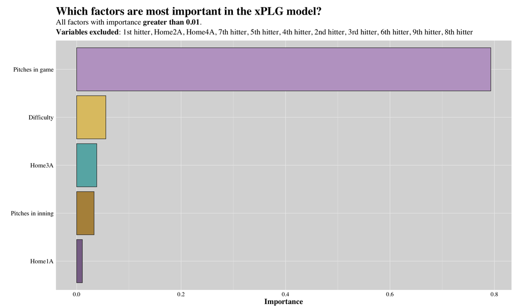

And here is a visualization of both the **xPLG** and the actual pitches left in the game.

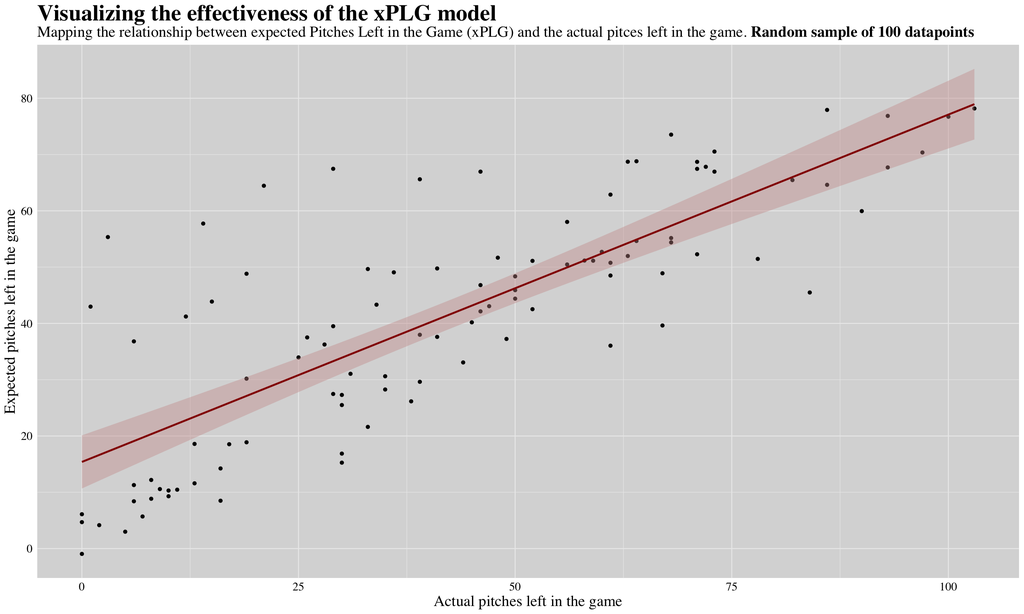

## Model 2 - xPLI

Now we do the same thing for our next model - The expected pitches left in the inning. The only difference is our label (outcome) variable changes from pitches left in the game to pitches left in the inning.

```r
xpli <- ready_data %>%
  select(label = pitches_left_in_inning, home_team, pitch_count, inning_count, difficulty, hitter_number)

head(xpli) %>%
  gt()
```

| label | home_team | pitch_count | inning_count | difficulty | hitter_number |
| --- | --- | --- | --- | --- | --- |
| 7 | Home3A | 1 | 1 | 20.11 | 1 |
| 17 | Home3A | 1 | 1 | 20.11 | 1 |
| 18 | Home3A | 1 | 1 | 20.11 | 1 |
| 17 | Home4A | 1 | 1 | 20.11 | 1 |
| 34 | Home2A | 1 | 1 | 20.11 | 1 |
| 13 | Home3A | 1 | 1 | 20.11 | 1 |

Now we convert necessary variables to factors.

```r
str(xpli)
```

```
## tibble [12,899 × 6] (S3: tbl_df/tbl/data.frame)
##  $ label        : int [1:12899] 7 17 18 17 34 13 13 18 11 15 ...
##  $ home_team    : chr [1:12899] "Home3A" "Home3A" "Home3A" "Home4A" ...
##  $ pitch_count  : int [1:12899] 1 1 1 1 1 1 1 1 1 1 ...
##  $ inning_count : int [1:12899] 1 1 1 1 1 1 1 1 1 1 ...
##  $ difficulty   : num [1:12899] 20.1 20.1 20.1 20.1 20.1 ...
##  $ hitter_number: num [1:12899] 1 1 1 1 1 1 1 1 1 1 ...
```

```r
xpli$home_team <- as.factor(xpli$home_team)
xpli$hitter_number <- as.factor(xpli$hitter_number)
xpli$label <- as.integer(xpli$label)
dmy_2 <- dummyVars(" ~ .", data = xpli)
xpli_final <- data.frame(predict(dmy_2, newdata = xpli))
str(xpli_final)
```

```
## 'data.frame':    12899 obs. of  17 variables:
##  $ label           : num  7 17 18 17 34 13 13 18 11 15 ...
##  $ home_team.Home1A: num  0 0 0 0 0 0 0 0 0 0 ...
##  $ home_team.Home2A: num  0 0 0 0 1 0 1 0 0 1 ...
##  $ home_team.Home3A: num  1 1 1 0 0 1 0 1 0 0 ...
##  $ home_team.Home4A: num  0 0 0 1 0 0 0 0 1 0 ...
##  $ pitch_count     : num  1 1 1 1 1 1 1 1 1 1 ...
##  $ inning_count    : num  1 1 1 1 1 1 1 1 1 1 ...
##  $ difficulty      : num  20.1 20.1 20.1 20.1 20.1 ...
##  $ hitter_number.1 : num  1 1 1 1 1 1 1 1 1 1 ...
##  $ hitter_number.2 : num  0 0 0 0 0 0 0 0 0 0 ...
##  $ hitter_number.3 : num  0 0 0 0 0 0 0 0 0 0 ...
##  $ hitter_number.4 : num  0 0 0 0 0 0 0 0 0 0 ...
##  $ hitter_number.5 : num  0 0 0 0 0 0 0 0 0 0 ...
##  $ hitter_number.6 : num  0 0 0 0 0 0 0 0 0 0 ...
##  $ hitter_number.7 : num  0 0 0 0 0 0 0 0 0 0 ...
##  $ hitter_number.8 : num  0 0 0 0 0 0 0 0 0 0 ...
##  $ hitter_number.9 : num  0 0 0 0 0 0 0 0 0 0 ...
```

```r
smp_size_2 <- floor(0.80 * nrow(xpli_final))
set.seed(617)
indices_2 <- sample(seq_len(nrow(xpli_final)), size = smp_size)
train_2 <- as.matrix(xpli_final[indices, ])
test_2 <- as.matrix(xpli_final[-indices, ])
```

Time to conduct the xPLI model. Keep in mind the parameters of the xPLI model will ne different from the xPLG model - It all depends on optimizing RMSE.

```r
xpli_model <-
  xgboost(
    data = train_2[, 2:17],
    label = train_2[, 1],
    nrounds = 230,
    objective = "reg:squarederror",
    early_stopping_rounds = 3,
    max_depth = 6,
    eta = .18
  )

set.seed(617)
cv_model2 <- xgb.cv(
  data = train_2[, 2:17],
  label = train_2[, 1],
  nrounds = 1000,
  nfold = 5,
  objective = "reg:squarederror",
  early_stopping_rounds = 10,
  max_depth = 6,
  eta = 0.1,
  eval_metric = "rmse",
  verbose = 1
)
```

Let’s look at the important factors and once again fit the model onto the test dataset.

```r
xgb.importance(model = xpli_model) %>%
  gt()
```

| Feature | Gain | Cover | Frequency |
| --- | --- | --- | --- |
| difficulty | 0.512285869 | 0.25482206 | 0.18278563 |
| inning_count | 0.191325507 | 0.16511934 | 0.15520177 |
| pitch_count | 0.150458880 | 0.35535115 | 0.33969011 |
| home_team.Home3A | 0.020626068 | 0.02069147 | 0.04026903 |
| home_team.Home1A | 0.017148150 | 0.01374047 | 0.04205687 |
| home_team.Home4A | 0.014655486 | 0.01494120 | 0.03107441 |
| home_team.Home2A | 0.014575145 | 0.01983091 | 0.04103525 |
| hitter_number.5 | 0.011344412 | 0.01783044 | 0.02119871 |
| hitter_number.4 | 0.011326475 | 0.01848244 | 0.02017708 |
| hitter_number.6 | 0.010304756 | 0.01576634 | 0.02187979 |
| hitter_number.2 | 0.010161508 | 0.01468534 | 0.01966627 |
| hitter_number.9 | 0.007974709 | 0.01666913 | 0.01770816 |
| hitter_number.3 | 0.007828910 | 0.01314098 | 0.01821897 |
| hitter_number.7 | 0.007565220 | 0.01716803 | 0.01634599 |
| hitter_number.1 | 0.006312907 | 0.02035825 | 0.01643113 |
| hitter_number.8 | 0.006105997 | 0.02140245 | 0.01626085 |

```r
pred_xgb_2 <- predict(xpli_model, test_2[, 2:17])
```

Finding the RMSE.

```r
yhat_2 <- pred_xgb_2
y_2 <- test_2[, 1]
postResample(yhat_2, y_2)
```

```
##     RMSE Rsquared      MAE
## 4.709729 0.506557 3.378450
```

```r
pitches_left_in_inning <- as.data.frame(
  matrix(predict(xpli_model, as.matrix(xpli_final %>% select(-label))))
) %>%
  dplyr::rename(xPLI = V1)
```

And now we join the xPLI values with their corresponding entries.

```r
joined_xpli <- cbind(xpli_final, pitches_left_in_inning)
```

Here is a visualization of the important features in our **xPLI** model.

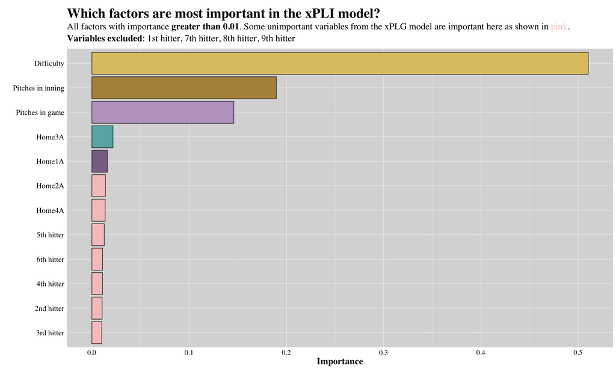

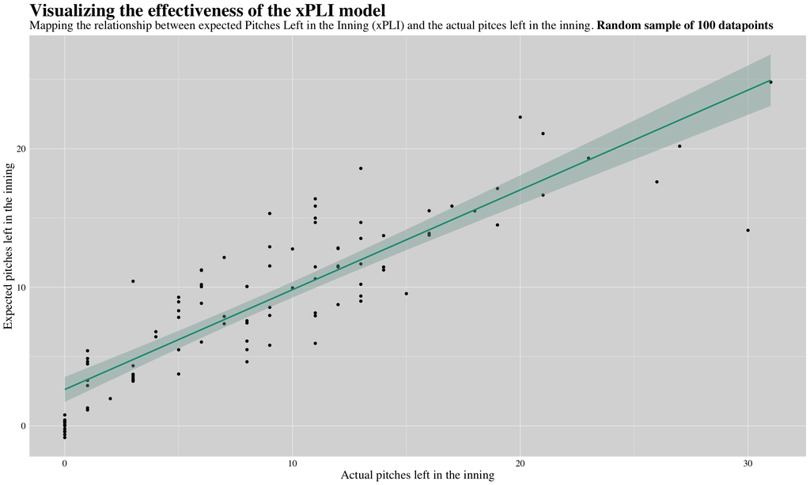

## Analyzing the data

Next, we join the xPLI and xPLG values with the original data We now have the xPLI and xPLG metrics for every observation, how do we determine when to pull the pitcher? Well, we decided if the xPLG was less than the xPLI, then it would be time to pull the pitcher. If the pitcher does not have enough juice to make it through the inning, they should be pulled.

```r
all_data <- cbind(joined_data_placeholder, pitches_left_in_inning)

expected_values <- select(all_data, xPLG, xPLI)
final_data <- cbind(ready_data, expected_values)

#Putting out our recommendation
final_data <- final_data %>%
  mutate(pull_pitcher = ifelse(xPLG < xPLI, 1, 0))

final_data <- final_data %>%
  group_by(game_str) %>%
  mutate(actual_pulling = ifelse(row_number() == n(), 1, 0)) %>%
  ungroup()

#Creating another metric to show around how close a pitcher is to getting pulled.
final_data <- final_data %>%
  mutate(expected_difference = xPLG - xPLI)
```

How successful was the model? As the below table shows, pretty successful.

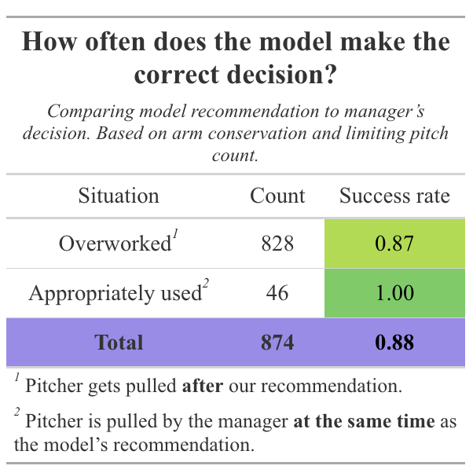

Next, we wanted to see how hard teams worked their pitchers, so we created a metric called “pitches over expected” or poe for short. We ended up finding out that pitchers tended to be overworked, going beyond our model’s recommendations.

```r
#Creating the Poe variable - If there is no pulling involved, we put an NA value in the column so it is easy to summarize
test123 <- final_data %>%
  group_by(game_str) %>%
  mutate(
    poe = ifelse(pull_pitcher == 1 & actual_pulling == 0, pitches_left_in_game, NA)) %>%
  mutate(
    poe = ifelse(is.na(poe) & pull_pitcher == 0 & actual_pulling == 1, -xPLG, poe)) %>%
  mutate(
    poe = ifelse(is.na(poe) & pull_pitcher == 1 & actual_pulling == 1, 0, poe)) %>%
  ungroup()

#We only want to look at the FIRST recommendation
retain_first_numeric <- function(x) {
  # Identify positions of non-NA numeric values
  numeric_positions <- which(!is.na(x) & is.numeric(x))

  # Create a logical vector for replacement
  retain <- rep(NA, length(x))
  if(length(numeric_positions) > 0) {
    retain[numeric_positions[1]] <- x[numeric_positions[1]]
  }
  retain
}


# Apply the function to each group
result <- test123 %>%
  group_by(game_str) %>%
  mutate(poe = retain_first_numeric(poe)) %>%
  ungroup()
mean_poe <- mean(result$poe, na.rm = T)
sd_poe <- sd(result$poe, na.rm = T)

#Filtering out outliers
filtered_result <- filter(result, result$poe < mean_poe + 2*sd_poe & result$poe > mean_poe - 2*sd_poe)

#Let's look at the poe of every pitching outing and see what it tells us.
pitchers <- filtered_result %>%
  group_by(pitcher, HomeTeam) %>%
  summarize (poe = mean(poe, na.rm = T))
```

And here is the visualization of pitcher outings. As we can see, pitchers tend to be overworked more often than not.

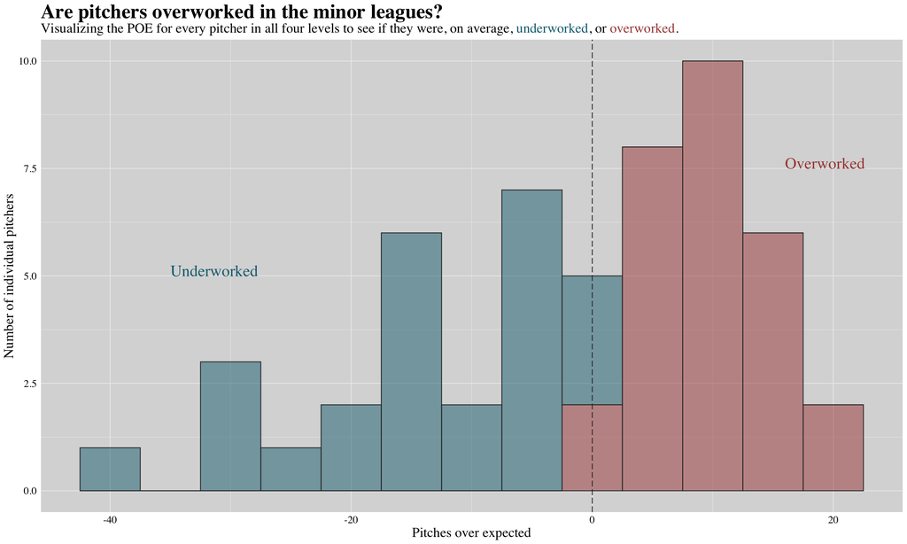

This is confirmed as majority of pitchers are overworked in the minor leagues.

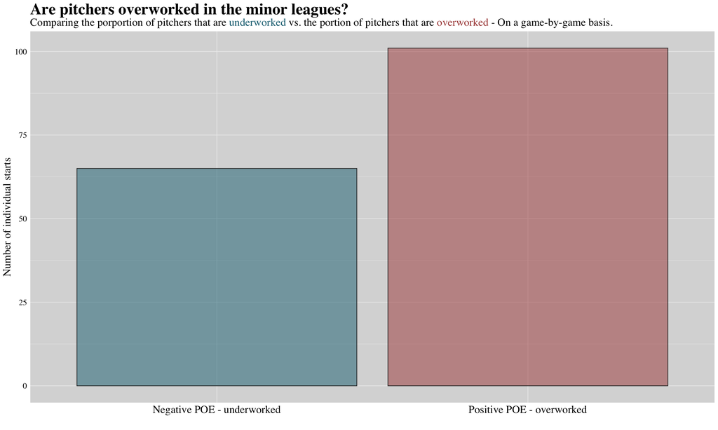

Now let’s look at how overworked pitchers are on a team level.

```r
#Create a variable that shows if pitchers were overworked or underworked
filtered_result$diff <- ifelse(filtered_result$poe > 0 | filtered_result$poe == 0, 1, 0)

#Now do teams, on average, overwork their pitchers? Answer: Yes.
teams <- filtered_result %>%
  group_by(HomeTeam) %>%
  summarize (poe = mean(poe, na.rm = T))
```

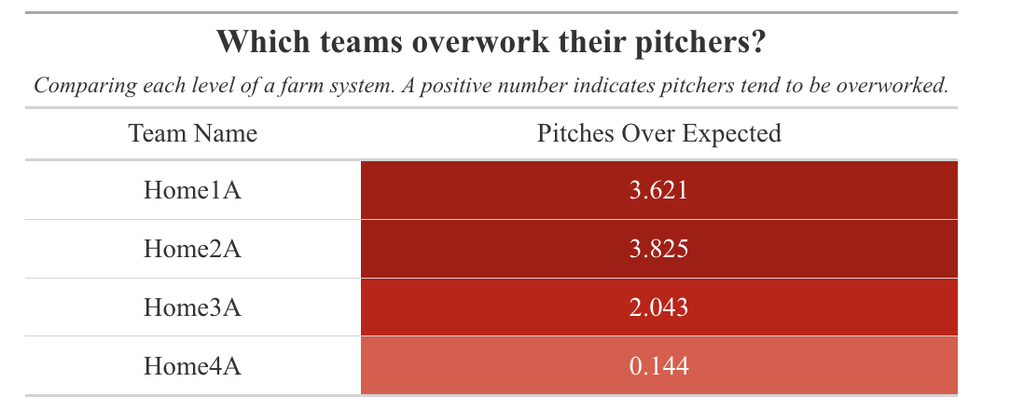

As we can see, all levels of the farm system tend to overwork their pitchers.